# SOC controls across Washington

Anthony Stewart

2023-11-19

### Introduction

Mapping soil organic carbon (SOC) as a function climatic, topographic, and geologic factors across spatial extents is key for identifying vulnerable SOC stocks. Yet, large, vulnerable SOC stocks are contained in the organic soils of wetlands and can occur in close proximity to non-wetland soils but are controlled and function differently due to saturated soil conditions. Thus, wetland SOC is often omitted or underrepresented in SOC mapping and modeling making it difficult to assess controls compared to non-wetland soil types. Here, we use geospatial data and SOC stocks from 481 soil horizons in 96 pedons in both wetlands and non-wetlands across three ecoregion study areas of the Pacific Northwest to assess climatic, geologic, and topographic controls on SOC.

### Hypotheses

1. WIP is a significant predictor of SOC stock
2. WIP interaction with climate (Precip & Temp) is a significant predictor of SOC stock
3. Geology is a significant predictor of SOC stock

### Data

This dataset has observations of SOC% and SOC stock for 96 locations in Washington state. There are geospatial covariates as well that are used to build models to predict SOC% and/or SOC stock

```
## 'data.frame':    481 obs. of  25 variables:
##  $ X                   : int  1 2 3 4 5 6 7 8 9 10 ...
##  $ sample_ID           : chr  "H-C-01-DNR-WET" "H-C-01-DNR-WET" "H-C-01-DNR-WET" "H-C-01-DNR-WET" ...
##  $ site                : chr  "HOH" "HOH" "HOH" "HOH" ...
##  $ depth_cm            : int  13 40 76 104 11 30 45 75 9 27 ...
##  $ helper              : chr  "H-C-01-DNR-WET|13" "H-C-01-DNR-WET|40" "H-C-01-DNR-WET|76" "H-C-01-DNR-WET|104" ...
##  $ thickness_cm        : int  13 27 36 28 11 19 15 30 9 18 ...
##  $ rock_perc           : num  0 0 5 40 0 15 40 55 0 0 ...
##  $ BD_g_cm3            : num  0.07 0.16 0.51 0.88 0.38 0.49 0.7 0.57 0.72 0.95 ...
##  $ field_texture       : chr  "P" "MP" "MM" "C" ...
##  $ field_texture_binned: chr  "O" "O" "O" "C" ...
##  $ redox               : chr  NA NA NA NA ...
##  $ carbon_perc         : num  39.56 38.31 12.14 2.37 15.65 ...
##  $ carbon_stock_g_cm2  : num  0.376 1.678 2.105 0.352 0.65 ...
##  $ NDYI                : num  0.543 0.543 0.543 0.543 0.579 ...
##  $ Geomorphon_Class    : int  10 10 10 10 10 10 10 10 10 10 ...
##  $ Temp                : num  10.2 10.2 10.2 10.2 10.2 ...
##  $ Precip              : num  3070 3070 3070 3070 3054 ...
##  $ NDVI                : num  0.84 0.84 0.84 0.84 0.862 ...
##  $ MNDWI               : num  -0.477 -0.477 -0.477 -0.477 -0.446 ...
##  $ EVI                 : num  0.455 0.455 0.455 0.455 0.534 ...
##  $ SCI                 : num  0.649 0.649 0.649 0.649 0.648 ...
##  $ GEOLOGIC_AGE        : chr  "Pleistocene" "Pleistocene" "Pleistocene" "Pleistocene" ...
##  $ WIP                 : num  0.873 0.873 0.873 0.873 0.896 ...
##  $ x                   : num  411350 411350 411350 411350 409931 ...
##  $ y                   : num  5295086 5295086 5295086 5295086 5294415 ...
```

Examining covariate predictors using correlation plots

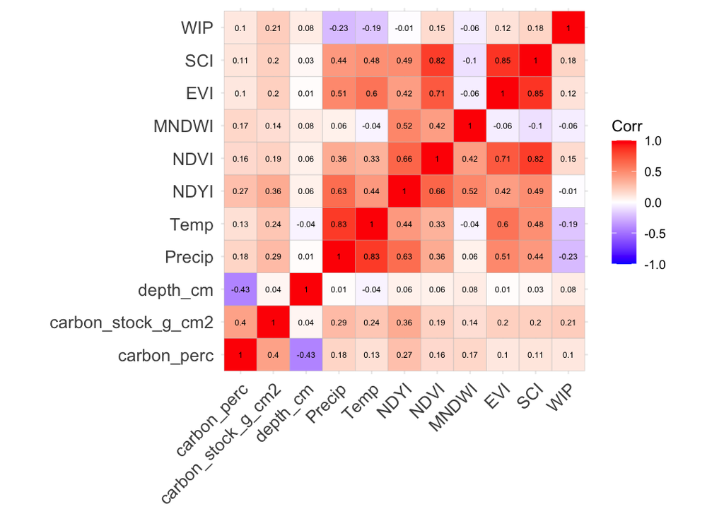

```r
wa_dat_num <- wa_dat |>
    dplyr::select(carbon_perc, carbon_stock_g_cm2, depth_cm,
        Precip, Temp, NDYI, NDVI, MNDWI, EVI, SCI, WIP) |>
    as.matrix()

ggcorrplot(cor(wa_dat_num), method = "square", type = "full",
    lab = T, lab_size = 2)
```

There is weak correlation between `carbon_stock_g_cm2` and the selected covariates. Additionally there is some collinearity between predictors. The spectral predictors such as EVI (Enhanced Vegetation Index) and SCI (Soil Condition Index) are well correlated with each other and also with NDVI (Normalized Difference Vegetation Index). We can remove these based on the correlation coefficient > 0.7.

Now we can begin examining the distribution of carbon stock values in the dataset to choose the approriate transformation. We also scale and center the numeric predictor variables.

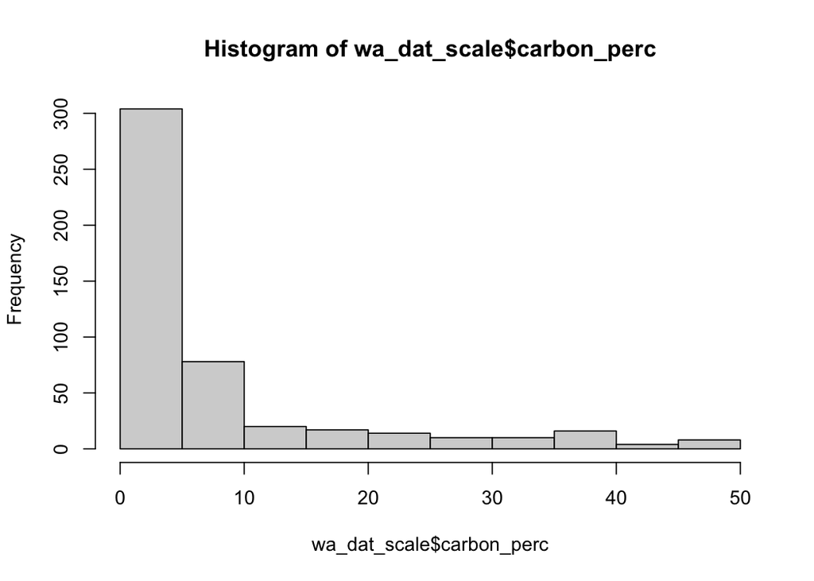

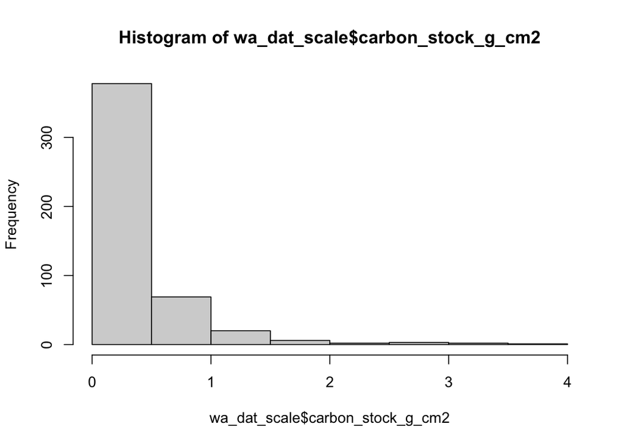

```r
columns_to_exclude <- c("carbon_perc", "carbon_stock_g_cm2")

wa_dat_scale <- wa_dat |>
    dplyr::mutate(across(dplyr::where(is.numeric) & !all_of(columns_to_exclude),
        ~dplyr::case_when(TRUE ~ scale(.))))

hist(wa_dat_scale$carbon_perc)  #not of interest but taking a look
hist(wa_dat_scale$carbon_stock_g_cm2)
```

Now build models using log transformed carbon stock data. We need to specify that `sample_ID` is a random effect because of the multiple samples at one location. `depth` can be a random slope to adjust model based on how it is affected by depth. We could use a Generalized Linear Model or a Generalized Linear Mixed Model here too but they often fail to converge. I am starting with the log-transformed linear mixed model first to test the hypotheses

```r
mod1 <- lmer(log(carbon_stock_g_cm2) ~ WIP * Precip * Temp +
    MNDWI + NDVI + NDYI + (GEOLOGIC_AGE) + (1 + (depth_cm) |
    sample_ID), data = wa_dat_scale, REML = F)
# No interactions
mod2 <- lmer(log(carbon_stock_g_cm2) ~ WIP + Precip + Temp +
    MNDWI + NDVI + NDYI + (GEOLOGIC_AGE) + (1 + (depth_cm) |
    sample_ID), data = wa_dat_scale, REML = F)
# No spectral
mod3 <- lmer(log(carbon_stock_g_cm2) ~ WIP * Precip * Temp +
    (GEOLOGIC_AGE) + (1 + (depth_cm) | sample_ID), data = wa_dat_scale,
    REML = F)
# No geology
mod4 <- lmer(log(carbon_stock_g_cm2) ~ WIP * Precip * Temp +
    MNDWI + NDVI + NDYI + (1 + (depth_cm) | sample_ID), data = wa_dat_scale,
    REML = F)
# No WIP w/ interaction
mod5 <- lmer(log(carbon_stock_g_cm2) ~ Precip * Temp + MNDWI +
    NDVI + NDYI + (GEOLOGIC_AGE) + (1 + (depth_cm) | sample_ID),
    data = wa_dat_scale, REML = F)
# No WIP w/o interaction
mod6 <- lmer(log(carbon_stock_g_cm2) ~ Precip + Temp + MNDWI +
    NDVI + NDYI + (GEOLOGIC_AGE) + (1 + (depth_cm) | sample_ID),
    data = wa_dat_scale, REML = F)
# No climate
mod7 <- lmer(log(carbon_stock_g_cm2) ~ WIP + MNDWI + NDVI + NDYI +
    (GEOLOGIC_AGE) + (1 + (depth_cm) | sample_ID), data = wa_dat_scale,
    REML = F)
# No climate No spectral
mod8 <- lmer(log(carbon_stock_g_cm2) ~ WIP + (GEOLOGIC_AGE) +
    (1 + (depth_cm) | sample_ID), data = wa_dat_scale, REML = F)
# Just WIP
mod9 <- lmer(log(carbon_stock_g_cm2) ~ WIP + (1 + (depth_cm) |
    sample_ID), data = wa_dat_scale, REML = F)
```

Pairwise comparisons between the top, global model and the rest. Note the table contains mod1 multiple times and has been encoded with an additional number

```r
anova_table_mod1 <- rbind(anova(mod1, mod2), #Not significant
                            anova(mod1, mod3), #
                            anova(mod1, mod4), #Significant
                            anova(mod1, mod5),#Significant
                            anova(mod1, mod6), #Significant
                            anova(mod1, mod7), #Significant
                            anova(mod1, mod8), #Significant
                            anova(mod1, mod9)) #Significant

anova_table_mod1 |>
    tibble::rownames_to_column(var = "models") |>
    dplyr::mutate(Significant = case_when(`Pr(>Chisq)` < 0.05 & `Pr(>Chisq)`>  0.01~ "*",
                                `Pr(>Chisq)` < 0.01 & `Pr(>Chisq)` > 0.001~ "**",
                                `Pr(>Chisq)` < 0.001 ~ "***",
                                .default = ""),
           Models = case_when(models == "mod11" ~ "mod1",
                              models == "mod12" ~ "mod1",
                              models == "mod13" ~ "mod1",
                              models == "mod14" ~ "mod1",
                              models == "mod15" ~ "mod1",
                              models == "mod16" ~ "mod1",
                              models == "mod17" ~ "mod1",
                              .default = models)) |>
    dplyr::select(-models) |>
    dplyr::select(Models, everything()) |>
    kbl() |>
    kable_classic_2("hover", full_width = F)
```

Models

npar

AIC

BIC

logLik

deviance

Chisq

Df

Pr(>Chisq)

Significant

mod2

16

1394.726

1461.540

-681.3628

1362.726

NA

NA

NA

mod1

20

1398.184

1481.701

-679.0918

1358.184

4.541993

4

0.3375972

mod3

17

1397.114

1468.104

-681.5572

1363.114

NA

NA

NA

mod1

20

1398.184

1481.701

-679.0918

1358.184

4.930755

3

0.1769384

mod4

15

1402.769

1465.407

-686.3847

1372.769

NA

NA

NA

mod1

20

1398.184

1481.701

-679.0918

1358.184

14.585647

5

0.0122876

mod5

16

1406.090

1472.904

-687.0450

1374.090

NA

NA

NA

mod1

20

1398.184

1481.701

-679.0918

1358.184

15.906251

4

0.0031476

mod6

15

1405.705

1468.343

-687.8523

1375.705

NA

NA

NA

mod1

20

1398.184

1481.701

-679.0918

1358.184

17.521028

5

0.0036107

mod7

14

1402.863

1461.325

-687.4314

1374.863

NA

NA

NA

mod1

20

1398.184

1481.701

-679.0918

1358.184

16.679065

6

0.0105380

mod8

11

1424.304

1470.238

-701.1519

1402.304

NA

NA

NA

mod1

20

1398.184

1481.701

-679.0918

1358.184

44.120165

9

0.0000013

***

mod9

6

1422.216

1447.271

-705.1081

1410.216

NA

NA

NA

mod1

20

1398.184

1481.701

-679.0918

1358.184

52.032483

14

0.0000028

***

From the ANOVAs it looks like `model 2` & `model 3` performed just as well as `model 1`meaning we should proceed with these. `model 2` removed interactions and `model 3` removed all the spectral metrics but kept interaction. However, `model 2` has 1 less parameter than `model 3` which gives it a lower AIC when compared together.

```r
anova(mod3, mod2) |>
    kbl() |>
    kable_classic_2("hover", full_width = F)
```

|  | npar | AIC | BIC | logLik | deviance | Chisq | Df | Pr(>Chisq) |
| --- | --- | --- | --- | --- | --- | --- | --- | --- |
| mod2 | 16 | 1394.726 | 1461.540 | -681.3628 | 1362.726 | NA | NA | NA |
| mod3 | 17 | 1397.114 | 1468.104 | -681.5572 | 1363.114 | 0 | 1 | 1 |

```r
# No MNDWI
mod2.1 <- lmer(log(carbon_stock_g_cm2) ~ WIP + Precip + Temp +
    NDVI + NDYI + (GEOLOGIC_AGE) + (1 + (depth_cm) | sample_ID),
    data = wa_dat_scale, REML = F)
# No MNDWI, No NDVI
mod2.2 <- lmer(log(carbon_stock_g_cm2) ~ WIP + Precip + Temp +
    NDYI + (GEOLOGIC_AGE) + (1 + (depth_cm) | sample_ID), data = wa_dat_scale,
    REML = F)
# No NDYI, No NDVI
mod2.3 <- lmer(log(carbon_stock_g_cm2) ~ WIP + Precip + Temp +
    MNDWI + (GEOLOGIC_AGE) + (1 + (depth_cm) | sample_ID), data = wa_dat_scale,
    REML = F)
# No NDYI, No MNDWI
mod2.4 <- lmer(log(carbon_stock_g_cm2) ~ WIP + Precip + Temp +
    NDVI + (GEOLOGIC_AGE) + (1 + (depth_cm) | sample_ID), data = wa_dat_scale,
    REML = F)
# No NDVI
mod2.5 <- lmer(log(carbon_stock_g_cm2) ~ WIP + Precip + Temp +
    NDYI + MNDWI + (GEOLOGIC_AGE) + (1 + (depth_cm) | sample_ID),
    data = wa_dat_scale, REML = F)
# No NDYI
mod2.6 <- lmer(log(carbon_stock_g_cm2) ~ WIP + Precip + Temp +
    NDVI + MNDWI + (GEOLOGIC_AGE) + (1 + (depth_cm) | sample_ID),
    data = wa_dat_scale, REML = F)
# No spectral
mod2.7 <- lmer(log(carbon_stock_g_cm2) ~ WIP + Precip + Temp +
    (GEOLOGIC_AGE) + (1 + (depth_cm) | sample_ID), data = wa_dat_scale,
    REML = F)
```

```r
anova_table_mod2 <- rbind(anova(mod2, mod2.1), #Not Significant
anova(mod2, mod2.2), #Not Significant
anova(mod2, mod2.3), #Not Significant
anova(mod2, mod2.4), #Not Significant
anova(mod2, mod2.5), #Not Significant
anova(mod2, mod2.6),
anova(mod2, mod2.7), make.row.names = T) #Not Significant

anova_table_mod2 |>
    mutate(Significant = case_when(`Pr(>Chisq)` < 0.05 & `Pr(>Chisq)`>  0.01~ "*",
                                `Pr(>Chisq)` < 0.01 & `Pr(>Chisq)` > 0.001~ "**",
                                `Pr(>Chisq)` < 0.001 ~ "***",
                                .default = "")) |>
  kbl() |>
  kable_classic_2("hover", full_width = F)
```

|  | npar | AIC | BIC | logLik | deviance | Chisq | Df | Pr(>Chisq) | Significant |
| --- | --- | --- | --- | --- | --- | --- | --- | --- | --- |
| mod2.1 | 15 | 1393.356 | 1455.994 | -681.6780 | 1363.356 | NA | NA | NA |  |
| mod2 | 16 | 1394.726 | 1461.540 | -681.3628 | 1362.726 | 0.6303396 | 1 | 0.4272308 |  |
| mod2.2 | 14 | 1391.475 | 1449.937 | -681.7375 | 1363.475 | NA | NA | NA |  |
| mod21 | 16 | 1394.726 | 1461.540 | -681.3628 | 1362.726 | 0.7492708 | 2 | 0.6875399 |  |
| mod2.3 | 14 | 1391.954 | 1450.417 | -681.9772 | 1363.954 | NA | NA | NA |  |
| mod22 | 16 | 1394.726 | 1461.540 | -681.3628 | 1362.726 | 1.2287240 | 2 | 0.5409859 |  |
| mod2.4 | 14 | 1394.233 | 1452.695 | -683.1163 | 1366.233 | NA | NA | NA |  |
| mod23 | 16 | 1394.726 | 1461.540 | -681.3628 | 1362.726 | 3.5070131 | 2 | 0.1731657 |  |
| mod2.5 | 15 | 1392.893 | 1455.531 | -681.4467 | 1362.893 | NA | NA | NA |  |
| mod24 | 16 | 1394.726 | 1461.540 | -681.3628 | 1362.726 | 0.1677554 | 1 | 0.6821144 |  |
| mod2.6 | 15 | 1393.914 | 1456.552 | -681.9568 | 1363.914 | NA | NA | NA |  |
| mod25 | 16 | 1394.726 | 1461.540 | -681.3628 | 1362.726 | 1.1879664 | 1 | 0.2757401 |  |
| mod2.7 | 13 | 1393.302 | 1447.588 | -683.6508 | 1367.302 | NA | NA | NA |  |
| mod26 | 16 | 1394.726 | 1461.540 | -681.3628 | 1362.726 | 4.5758474 | 3 | 0.2056238 |  |

Model 2.2 and 2.3 are the lowest AIC and not significantly different from the fit in Model 2. The choice is either between MNDWI or NDYI. For this, I want to see if WIP interacts with these variables.

```r
# No MNDWI, No NDVI
mod2.2.1 <- lmer(log(carbon_stock_g_cm2) ~ Precip + Temp + WIP:NDYI +
    (GEOLOGIC_AGE) + (1 + (depth_cm) | sample_ID), data = wa_dat_scale,
    REML = F)
# No NDYI, No NDVI
mod2.3.1 <- lmer(log(carbon_stock_g_cm2) ~ Precip + Temp + WIP:MNDWI +
    (GEOLOGIC_AGE) + (1 + (depth_cm) | sample_ID), data = wa_dat_scale,
    REML = F)
```

```r
anova_table_mod2ext <- rbind(anova(mod2.2, mod2.2.1), anova(mod2.3,
    mod2.3.1))

anova_table_mod2ext |>
    mutate(Significant = case_when(`Pr(>Chisq)` < 0.05 & `Pr(>Chisq)` >
        0.01 ~ "*", `Pr(>Chisq)` < 0.01 & `Pr(>Chisq)` > 0.001 ~
        "**", `Pr(>Chisq)` < 0.001 ~ "***", .default = "")) |>
    kbl() |>
    kable_classic_2("hover", full_width = F)
```

|  | npar | AIC | BIC | logLik | deviance | Chisq | Df | Pr(>Chisq) | Significant |
| --- | --- | --- | --- | --- | --- | --- | --- | --- | --- |
| mod2.2.1 | 13 | 1409.712 | 1463.998 | -691.8560 | 1383.712 | NA | NA | NA |  |
| mod2.2 | 14 | 1391.475 | 1449.937 | -681.7375 | 1363.475 | 20.23698 | 1 | 6.8e-06 | *** |
| mod2.3.1 | 13 | 1409.469 | 1463.755 | -691.7343 | 1383.469 | NA | NA | NA |  |
| mod2.3 | 14 | 1391.954 | 1450.417 | -681.9772 | 1363.954 | 19.51414 | 1 | 1.0e-05 | *** |

Doesn’t look like there are any significant interactions that improve model fit

Now we can look at the table of all models and compare AICs

| AIC | formula | name | delta |
| --- | --- | --- | --- |
| 1398.18 | WIP * Precip * Temp + MNDWI + NDVI + NDYI + (GEOLOGIC_AGE) + (1 + (depth_cm) \| sample_ID) | mod1 | 6.71 |
| 1394.73 | WIP + Precip + Temp + MNDWI + NDVI + NDYI + (GEOLOGIC_AGE) + (1 + (depth_cm) \| sample_ID) | mod2 | 3.26 |
| 1397.11 | WIP * Precip * Temp + (GEOLOGIC_AGE) + (1 + (depth_cm) \| sample_ID) | mod3 | 5.64 |
| 1402.77 | WIP * Precip * Temp + MNDWI + NDVI + NDYI + (1 + (depth_cm) \| sample_ID) | mod4 | 11.30 |
| 1406.09 | Precip * Temp + MNDWI + NDVI + NDYI + (GEOLOGIC_AGE) + (1 + (depth_cm) \| sample_ID) | mod5 | 14.62 |
| 1405.7 | Precip + Temp + MNDWI + NDVI + NDYI + (GEOLOGIC_AGE) + (1 + (depth_cm) \| sample_ID) | mod6 | 14.23 |
| 1402.86 | WIP + MNDWI + NDVI + NDYI + (GEOLOGIC_AGE) + (1 + (depth_cm) \| sample_ID) | mod7 | 11.39 |
| 1424.3 | WIP + (GEOLOGIC_AGE) + (1 + (depth_cm) \| sample_ID) | mod8 | 32.83 |
| 1422.22 | WIP + (1 + (depth_cm) \| sample_ID) | mod9 | 30.75 |
| 1393.36 | WIP + Precip + Temp + NDVI + NDYI + (GEOLOGIC_AGE) + (1 + (depth_cm) \| sample_ID) | mod2.1 | 1.89 |
| 1391.47 | WIP + Precip + Temp + NDYI + (GEOLOGIC_AGE) + (1 + (depth_cm) \| sample_ID) | mod2.2 | 0.00 |
| 1391.95 | WIP + Precip + Temp + MNDWI + (GEOLOGIC_AGE) + (1 + (depth_cm) \| sample_ID) | mod2.3 | 0.48 |
| 1394.23 | WIP + Precip + Temp + NDVI + (GEOLOGIC_AGE) + (1 + (depth_cm) \| sample_ID) | mod2.4 | 2.76 |
| 1392.89 | WIP + Precip + Temp + NDYI + MNDWI + (GEOLOGIC_AGE) + (1 + (depth_cm) \| sample_ID) | mod2.5 | 1.42 |
| 1393.91 | WIP + Precip + Temp + NDVI + MNDWI + (GEOLOGIC_AGE) + (1 + (depth_cm) \| sample_ID) | mod2.6 | 2.44 |
| 1393.3 | WIP + Precip + Temp + (GEOLOGIC_AGE) + (1 + (depth_cm) \| sample_ID) | mod2.7 | 1.83 |
| 1409.71 | Precip + Temp + WIP:NDYI + (GEOLOGIC_AGE) + (1 + (depth_cm) \| sample_ID) | mod2.2.1 | 18.24 |
| 1409.47 | Precip + Temp + WIP:MNDWI + (GEOLOGIC_AGE) + (1 + (depth_cm) \| sample_ID) | mod2.3.1 | 18.00 |

Looks like the best model according to AIC is the `mod2.2` or `mod2.3` which do not include any interactions. The model $R^2$ is 0.6991998 and the fit looks fairly good on a log-based plot

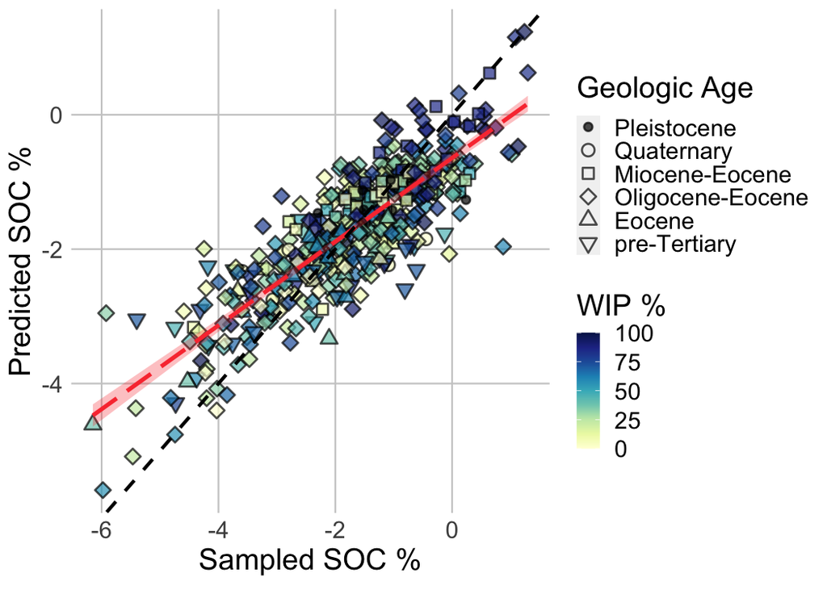

The `dredge` function can be used to look through mutliple combinations of models, but this may produce spurious results

```r
gmod <- lmer(log(carbon_stock_g_cm2) ~ WIP * Temp * Precip *
    NDYI + GEOLOGIC_AGE + (1 + (depth_cm) | sample_ID), data = wa_dat_scale,
    REML = F, na.action = "na.fail")
x <- dredge(gmod, beta = "sd")
```

```r
head(x) |>
    kbl() |>
    kable_classic_2("hover", full_width = F)
dmod <- get.models(x, 1)[[1]]
```

[output not shown]

The dredge model `dmod` shows that the “best” model includes GEOLOGIC_AGE, Precip, NDYI and WIP. No interactions were found between all the continous variables.

```r
summary(dmod)
```

```
## Linear mixed model fit by maximum likelihood . t-tests use Satterthwaite's
##   method [lmerModLmerTest]
## Formula: log(carbon_stock_g_cm2) ~ GEOLOGIC_AGE + NDYI + Precip + WIP +
##     (1 + (depth_cm) | sample_ID)
##    Data: wa_dat_scale
##
##      AIC      BIC   logLik deviance df.resid
##   1389.5   1443.8   -681.7   1363.5      468
##
## Scaled residuals:
##     Min      1Q  Median      3Q     Max
## -3.7279 -0.5370 -0.0231  0.6107  3.5603
##
## Random effects:
##  Groups    Name        Variance Std.Dev. Corr
##  sample_ID (Intercept) 0.6460   0.8037
##            depth_cm    0.5063   0.7116   0.94
##  Residual              0.6353   0.7971
## Number of obs: 481, groups:  sample_ID, 96
##
## Fixed effects:
##                               Estimate Std. Error        df t value Pr(>|t|)
## (Intercept)                   -1.19612    0.35329 115.77478  -3.386 0.000970
## GEOLOGIC_AGEMiocene-Eocene    -1.06805    0.50491 109.01031  -2.115 0.036679
## GEOLOGIC_AGEOligocene-Eocene   0.20606    0.39008 114.24588   0.528 0.598340
## GEOLOGIC_AGEPleistocene       -0.06438    0.35977 114.86731  -0.179 0.858286
## GEOLOGIC_AGEpre-Tertiary      -0.02528    0.47373  89.71128  -0.053 0.957567
## GEOLOGIC_AGEQuaternary        -0.60420    0.42719 108.01961  -1.414 0.160134
## NDYI                           0.16894    0.08341  91.29017   2.025 0.045755
## Precip                         0.33661    0.08527  91.16163   3.948 0.000155
## WIP                            0.24328    0.06576  90.09404   3.700 0.000371
##
## (Intercept)                  ***
## GEOLOGIC_AGEMiocene-Eocene   *
## GEOLOGIC_AGEOligocene-Eocene
## GEOLOGIC_AGEPleistocene
## GEOLOGIC_AGEpre-Tertiary
## GEOLOGIC_AGEQuaternary
## NDYI                         *
## Precip                       ***
```

[output cut: 8 more lines]

```
## GEOLOGIC_AGEP -0.981  0.673         0.877
## GEOLOGIC_AGE- -0.747  0.493         0.667         0.733
## GEOLOGIC_AGEQ -0.859  0.579         0.751         0.840         0.640
## NDYI          -0.122  0.112         0.030         0.112         0.125
## Precip         0.075 -0.196        -0.012        -0.067         0.041
## WIP            0.120  0.038        -0.064        -0.113        -0.034
##               GEOLOGIC_AGEQ NDYI   Precip
## GEOLOGIC_AGEM
## GEOLOGIC_AGEO
## GEOLOGIC_AGEP
## GEOLOGIC_AGE-
## GEOLOGIC_AGEQ
## NDYI           0.277
## Precip        -0.195        -0.662
## WIP           -0.255        -0.269  0.309
```

Looks like there is a pretty good $R^2$ of 0.6992898 for the model

Formula:

```r
print(formula(dmod))
```

```
## log(carbon_stock_g_cm2) ~ GEOLOGIC_AGE + NDYI + Precip + WIP +
##     (1 + (depth_cm) | sample_ID)
```

```r
r.sq(log(wa_dat_scale$carbon_stock_g_cm2), fitted(dmod))
```

```
## [1] 0.6992898
```

[figure not shown]

```r
library(RColorBrewer)
ggplot(wa_dat_scale, aes(y = (fitted(dmod)), x = log(carbon_stock_g_cm2))) +
    geom_jitter(color='black',
               aes(fill = (wa_dat$WIP*100), shape = as.factor(GEOLOGIC_AGE)),
               size = 3, stroke = 0.9, alpha = 0.7) +
    scale_fill_gradientn(colours = brewer.pal(9, "YlGnBu"),
                         name = "WIP %", n.breaks = 5, limits = c(0, 100)) +
     scale_shape_manual(name = "Geologic Age",
                        values = c(20, 21, 22, 23, 24, 25),
                        labels= c("Pleistocene", "Quaternary",
                                  "Miocene-Eocene", "Oligocene-Eocene",
                                  "Eocene", "pre-Tertiary" )) +
    geom_smooth(aes(y = (fitted(dmod)), x = log(carbon_stock_g_cm2)),
                method = "lm", color = "#fa3e3e", fill = "#fa3e3e",
                size = 1.2, linetype = 5, alpha = 0.3, se = T) +
    xlab(expression('Sampled SOC %'))+ #(MgC ha'^-1*')')) +
    ylab(expression('Predicted SOC %'))+ #(MgC ha'^-1*')')) +
    geom_abline(intercept = 0, slope = 1, linewidth = 1, linetype = "dashed") +
    #xlim(-4, 5) +
    #ylim(-4, 5)  +
    guides(guide_legend(byrow = TRUE)) +
    theme(legend.position = 'right',
          legend.key.size = unit(1.7, "cm"),
          panel.background = element_blank(),
          panel.grid.major = element_line(colour = "grey80"),
          axis.ticks = element_blank(),
          text = element_text(size = 18))
```

I also want to try Random Forest in order to see if there are non-linear relationships with SOC and other variables.

`depth_cm` is included as a predictor here in the data setup

```r
tuneRF(x = full[, 2:ncol(full)], y = (full$carbon_stock_g_cm2),
    mtryStart = 3, ntreeTry = 500, stepFactor = 1.5, improve = 1e-04)
```

```
## mtry = 3  OOB error = 0.8497408
## Searching left ...
## mtry = 2     OOB error = 0.8899713
## -0.04734443 1e-04
## Searching right ...
## mtry = 4     OOB error = 0.8430303
## 0.007897098 1e-04
## mtry = 6     OOB error = 0.8229766
## 0.02378764 1e-04
## mtry = 9     OOB error = 0.8223871
## 0.0007163724 1e-04
## mtry = 10    OOB error = 0.8232636
## -0.001065907 1e-04
```

```
##    mtry  OOBError
## 2     2 0.8899713
## 3     3 0.8497408
## 4     4 0.8430303
## 6     6 0.8229766
## 9     9 0.8223871
## 10   10 0.8232636
```

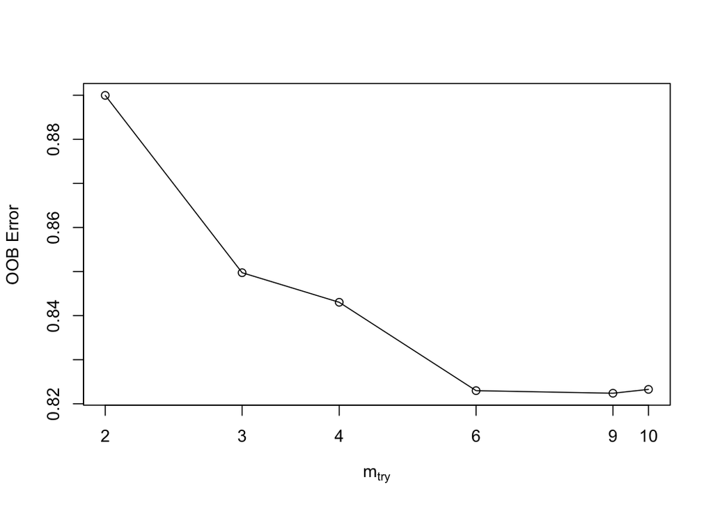

```r
rf_model <- randomForest((carbon_stock_g_cm2) ~ ., ntree = 1000,
    mtry = 9, importance = TRUE, data = full)


rf_model
```

```
##
## Call:
##  randomForest(formula = (carbon_stock_g_cm2) ~ ., data = full,      ntree = 1000, mtry = 9, importance = TRUE)
##                Type of random forest: regression
##                      Number of trees: 1000
## No. of variables tried at each split: 9
##
##           Mean of squared residuals: 0.8270089
##                     % Var explained: 50.93
```

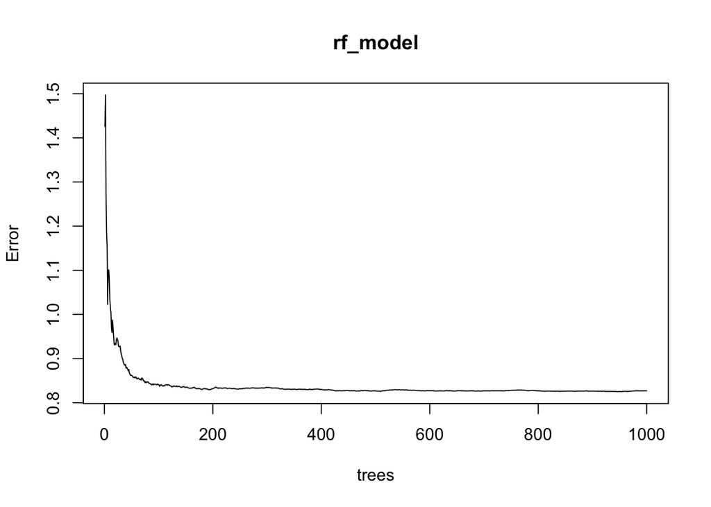

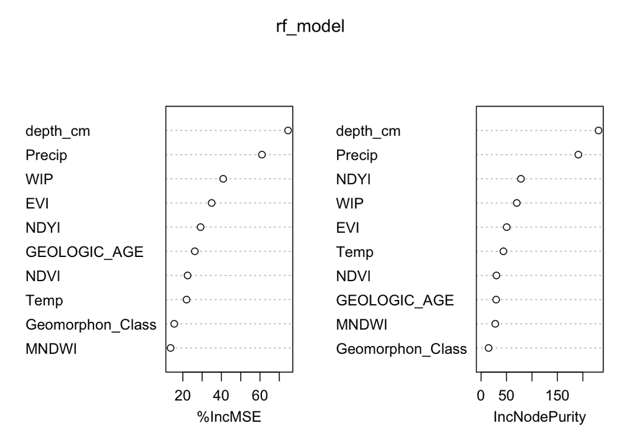

```r
plot(rf_model)
varImpPlot(rf_model)
```

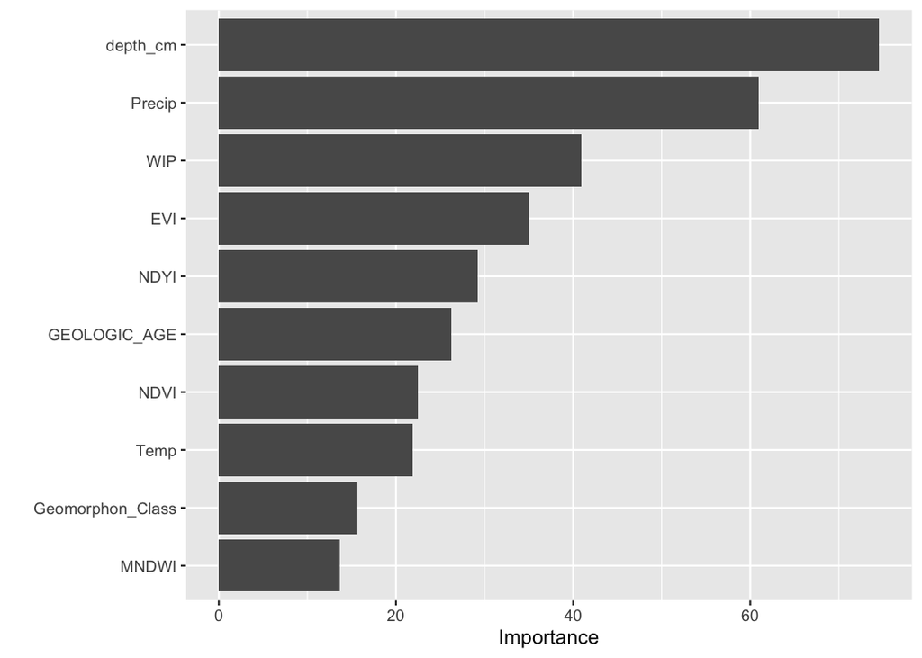

```r
vip::vip(rf_model)
```

Look at partial dependency plots

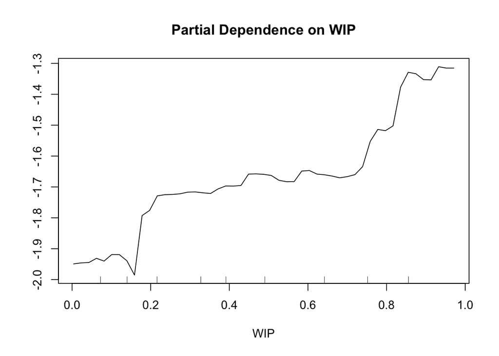

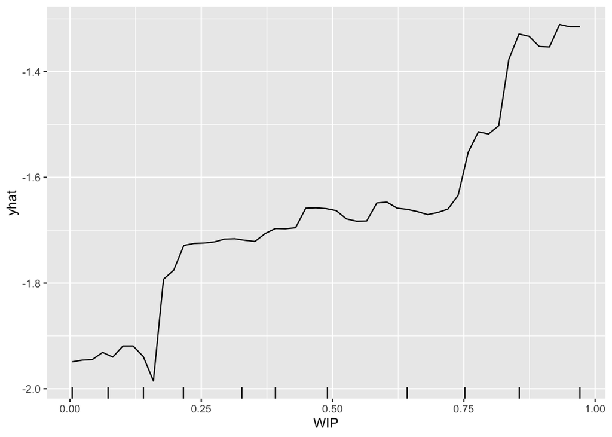

```r
randomForest::partialPlot(rf_model, full, WIP)
# randomForest::partialPlot(rf_model, full, Precip)
# randomForest::partialPlot(rf_model, full, Temp)
# randomForest::partialPlot(rf_model, full, NDYI)
# randomForest::partialPlot(rf_model, full, MNDWI)

rf_model |>
    pdp::partial(pred.var = c("WIP"), train = full) |>
    ggplot2::autoplot(rug = T, train = full)
```

```r
rf.predtrain <- predict(rf_model, newdata = train)
rf.predtest <- predict(rf_model, newdata = test)
```

```r
paste0(round(mean((rf.predtrain - log(train$carbon_stock_g_cm2))^2),
    3), " mean square error rf model from training")
```

```
## [1] "1.54 mean square error rf model from training"
```

```r
paste0(round(r.sq(log(train$carbon_stock_g_cm2), rf.predtrain),
    3), " R^2 rf model from training")
```

```
## [1] "0.134 R^2 rf model from training"
```

```r
paste0(round(r.sq(log(test$carbon_stock_g_cm2), rf.predtest),
    3), " R^2 rf model from testing ")
```

```
## [1] "0.099 R^2 rf model from testing "
```

```r
rf.full <- predict(rf_model, newdata = wa_dat)
```

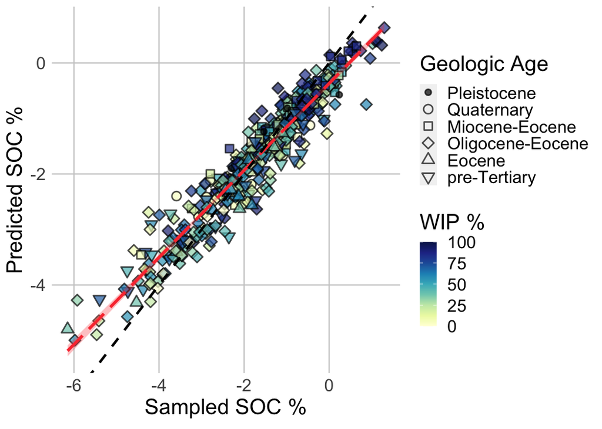

```r
library(RColorBrewer)
ggplot(wa_dat_scale, aes(y = (rf.full), x = log(carbon_stock_g_cm2))) +
    geom_jitter(color='black',
               aes(fill = (wa_dat$WIP*100), shape = as.factor(GEOLOGIC_AGE)),
               size = 3, stroke = 0.9, alpha = 0.7) +
    scale_fill_gradientn(colours = brewer.pal(9, "YlGnBu"),
                         name = "WIP %", n.breaks = 5, limits = c(0, 100)) +
    scale_shape_manual(name = "Geologic Age",
                        values = c(20, 21, 22, 23, 24, 25),
                        labels= c("Pleistocene", "Quaternary",
                                  "Miocene-Eocene", "Oligocene-Eocene",
                                  "Eocene", "pre-Tertiary" )) +
    geom_smooth(aes(y = (rf.full), x = log(carbon_stock_g_cm2)),
                method = "lm", color = "#fa3e3e", fill = "#fa3e3e",
                size = 1.2, linetype = 5, alpha = 0.3, se = T) +
    xlab(expression('Sampled SOC %'))+ #(MgC ha'^-1*')')) +
    ylab(expression('Predicted SOC %'))+ #(MgC ha'^-1*')')) +
    geom_abline(intercept = 0, slope = 1, linewidth = 1, linetype = "dashed") +
    #xlim(-4, 5) +
    #ylim(-4, 5)  +
    guides(guide_legend(byrow = TRUE)) +
    theme(legend.position = 'right',
          legend.key.size = unit(0.5, "cm"),
          panel.background = element_blank(),
          panel.grid.major = element_line(colour = "grey80"),
          axis.ticks = element_blank(),
          text = element_text(size = 18))
```